# VIBRANT Trial - Primary Analyses

Author

Laura Symul, Laura Vermeren, Susan Holmes

```r
library(tidyverse)
library(magrittr)
library(gt)
library(patchwork)
library(SummarizedExperiment)
library(tidySummarizedExperiment)
library(brms)
library(gtsummary)
library(labelled)
library(scales)
# library(gridExtra)
library(ggpubr)
# library(mia) # BiocManager::install("mia")

theme_set(theme_light())
tmp <- fs::dir_map("R", source)
```

```r
data_source <- "simulated"
```

# Introduction

This document presents the primary analyses of the VIBRANT trial.

Currently, this runs on simulated data, but the code is mostly ready to be run on the real data once it is available.

The simulated data is currently relatively realistic (but still needs some improvement), and is very optimistic (assumes a very successful trial).

These will be implemented once the corresponding improvement steps detailed above are themselves implemented.

Even with all these improvements, there will, inevitably, be un-anticipated issues with the real data, but the core of the methods (and corresponding code) will likely be unchanged.

## Workflow

The document is organized as follow

- Data preparation: load the raw data as provided by labs/teams, and collate them into a neat `MultiAssayExperiment` object containing all the data linked by `participant x visit`.
- Checks, QC, and Outcomes Definitions: check the data for potential issues, perform quality controls (e.g, check for library sizes, potential contamination, etc.), and define outcomes of interest (colonization status, etc.)
- Analyses: perform the primary analyses of the trial, including demographics, primary and secondary outcomes, and sensitivity analyses. This section has the main tables and figures.

# Data preparation

## Loading the data and creating `SummarizedExperiment` objects for each assays

In this section, we load the raw data from their original files (*i.e.,* the data/files as generated by the corresponding labs or teams) and transform each assay into a `SummarizedExperiment` object. This will enable to then collect them into a single `MultiAssayExperiment` object and perform the integrative analyses.

To link the assays together,we define a common unique identifier for each `participant x visit`. This unique identifier (`.sample`) is the concatenation of the `pid` (participant ID) and the `visit_code`.

### Clinical and survey (CRF) data

#### Information about the data

The `participants` table contains participant-invariant information such as the participant ID, the treatment arm, site, and study population (ITT, mITT, PP). The `visits` table contains participant-varying information collected at each visit.

The columns necessary for the primary trial analyses were then selected from these two and exported into two files: `participants.RDS` and `visits.RDS`, which we load below.

#### Loading the data

We load the `participant` and `visits` data, and create

- one table which will become the MAE’s colData
- one `SE` object which provides attendance information at each visit (this also ensures that the `MAE` object has data for all visits, which is useful for downstream analyses)

```r
participants <- readRDS(file = str_c(data_dir(), "00 clinical data/participants.RDS"))
visits <- readRDS(file = str_c(data_dir(), "00 clinical data/visits.RDS"))

clin <-
  participants |> left_join(visits, by = join_by(pid)) |>
  mutate(sample_id = str_c(pid, "_", visit_code), rownames = sample_id) |>
  dplyr::select(sample_id, everything())

mae_coldata <-
  clin |>
  as.data.frame() |>
  column_to_rownames(var = "rownames")
```

```r
make_se_clin <- function(clin, cols, assayname){
  assay <-
    clin |>
    dplyr::select(sample_id, all_of(cols)) |>
    as.data.frame() |>
    column_to_rownames("sample_id") |>
    t()

  assay_list <- list()
  assay_list[[assayname]] <- assay

  SummarizedExperiment::SummarizedExperiment(
    assays = assay_list
  )

}
```

```r
# Directly included in data simulation

# clin <- clin |> mutate(planned = TRUE, attended = ifelse(str_detect(visit_name, "Daily"), NA, attended)) #TRUE
```

```r
se_va <- make_se_clin(clin, cols = c("planned", "attended"), assayname = "visit_attendance")
```

### Weekly metagenomics data with LBP strains relative abundances

> TODO: add information about how the data was generated (summary of the methods)

We load the weekly metagenomics data, the manifest for the metagenomic barcodes, and the strain information.

```r
mg <- read_csv(str_c(data_dir(), "01 metagenomics kSanity/mg_kSanity.csv"))
mg_combined <- read_csv(str_c(data_dir(), "03 metagenomics combined/mg_combined.csv"))
mg_manifest <- read_csv(str_c(data_dir(), "01 metagenomics kSanity/mg_kSanity_manifest.csv"))
LBP_strain_info <- readxl::read_xlsx(str_c(dropbox_dir(), "9_VIBRANT_Study Product/IsolateNumbers.xlsx"))

LBP_strain_info <-
 LBP_strain_info |>
  mutate(strain_id = `VMRC ID`,
         LBP = ifelse(is.na(LC106), "LC-115", "LC-106 & LC-115") |> factor(),
         strain_origin = `Geographic source` |> factor()
  ) |>
  dplyr::rename(Biose_ID = `Biose ID`, VMRC_ID = `VMRC ID`) |>
  arrange(strain_origin, LBP) |>
  mutate(strain_id = strain_id |> fct_inorder()) |>
  dplyr::select(strain_id, LBP, strain_origin, contains("ID"))

LBP_strain_info |>   # gt(caption = "LBP strain information")
  set_variable_labels(
    strain_id = "Stain ID",
    strain_origin = "Strain origin",
    Biose_ID = "Biose ID",
    VMRC_ID = "VMRC ID"
  ) |>
  gt(caption = "LBP strain information") |>
  tab_style(style = cell_text(weight = "bold"),
            locations = cells_column_labels())
```

LBP strain information

| Stain ID | LBP | Strain origin | Biose ID | VMRC ID |
| --- | --- | --- | --- | --- |
| FF00018 | LC-106 & LC-115 | SA | GA08 | FF00018 |
| FF00051 | LC-106 & LC-115 | SA | GA09 | FF00051 |
| UC101_2_33 | LC-106 & LC-115 | SA | GA12 | UC101_2_33 |
| FF00004 | LC-115 | SA | GA07 | FF00004 |
| FF00064 | LC-115 | SA | GA10 | FF00064 |
| FF00072 | LC-115 | SA | GA11 | FF00072 |
| UC119_2_PB0238 | LC-115 | SA | GA13 | UC119_2_PB0238 |
| 122010_1999_16 | LC-115 | SA | GA14 | 122010_1999_16 |
| 185329_1999_17 | LC-115 | SA | GA15 | 185329_1999_17 |
| C0059E1 | LC-106 & LC-115 | US | GA03 | C0059E1 |
| C0022A1 | LC-106 & LC-115 | US | GA04 | C0022A1 |
| C0175A1 | LC-106 & LC-115 | US | GA06 | C0175A1 |
| C0006A1 | LC-115 | US | GA01 | C0006A1 |
| CC0028A1 | LC-115 | US | GA02 | CC0028A1 |
| C0112A1 | LC-115 | US | GA05 | C0112A1 |

```r
mg_to_SE <- function(mg,mg_combined, mg_manifest, LBP_strain_info, clin){
  mg_manifest <-
    mg_manifest |>
    mutate(sample_id = str_c(pid, "_", visit_code))

  if (any(duplicated(mg_manifest$sample_id))) stop("Duplicated `uid` in `mg_manifest`")

  mg <- mg |> left_join(mg_manifest, by = join_by(barcode))
  mg_combined <- mg_combined |> left_join(mg_manifest, by = join_by(barcode))

  tmp <- mg |> dplyr::select(barcode, sample_id) |> distinct()
  if (any(duplicated(tmp$sample_id))) stop("Duplicated `uid` in `mg`")

  # Add NA lines for missing samples
  all_sample_ids <-
    clin |>
    filter(!str_detect(visit_name, "Daily"), visit_abbr != "ST", day >= 0) |>
    select(sample_id) |>
    distinct() |>
    pull()

  mg <-
    mg |>
    tidyr::complete(sample_id = all_sample_ids)

  mg_combined <-
    mg_combined |>
    complete(sample_id = all_sample_ids)

  # create assays
  assay_prop_of_Lc <-
    mg |>
    dplyr::select(sample_id, everything()) |>
    dplyr::select(-c(pid, visit_code, barcode)) |>
    as.data.frame() |>
    column_to_rownames("sample_id") |>
    t()

  assay_unique_kmers <-
    mg_combined |>
    dplyr::select(sample_id, all_of(LBP_strain_info$strain_id)) |>  # `Lactobacillus crispatus`
    as.data.frame() |>
    column_to_rownames("sample_id") |>
    t()

  se_coldata <-
    mg |>
    dplyr::select(sample_id, barcode) |> #shared_kmers
    distinct() |>
    as.data.frame()

  se_rowdata <-
    mg |>
    dplyr::select(-c(barcode, pid, visit_code, sample_id)) |>
    colnames() |>
    as.data.frame() |>
    setNames("strain") |>
    distinct() |>
    left_join(
      LBP_strain_info,
      by = join_by(strain == strain_id)
    )

  # Harmonization of the order of samples and feature

  sorted_sample_ids <- sort(as.character(se_coldata$sample_id))
  assay_prop_of_Lc <- assay_prop_of_Lc[, sorted_sample_ids]
  assay_unique_kmers <- assay_unique_kmers[, sorted_sample_ids]
  se_coldata <- se_coldata[match(sorted_sample_ids, se_coldata$sample_id), ]

  sorted_strains <- assay_prop_of_Lc |> rownames() # sort(as.character(se_rowdata$strain))
  assay_prop_of_Lc <- assay_prop_of_Lc[sorted_strains, ]
  assay_unique_kmers <- assay_unique_kmers[sorted_strains, ]
  se_rowdata <- se_rowdata[match(sorted_strains, se_rowdata$strain), ]

  SummarizedExperiment::SummarizedExperiment(
    assays = list(prop_of_Lc = assay_prop_of_Lc, unique_kmers = assay_unique_kmers),
    rowData = se_rowdata,
    colData = se_coldata
  )
}
```

```r
(se_mg <- mg_to_SE(mg,mg_combined,  mg_manifest, LBP_strain_info, clin))
```

```
# A SummarizedExperiment-tibble abstraction: 13,635 × 11
# Features=15 | Samples=909 | Assays=prop_of_Lc, unique_kmers
   .feature       .sample prop_of_Lc unique_kmers sample_id barcode strain LBP
   <chr>          <chr>        <dbl>        <dbl> <chr>     <chr>   <chr>  <fct>
 1 FF00018        p1_1000          0            0 p1_1000   mg_p1_… FF000… LC-1…
 2 FF00051        p1_1000          0            0 p1_1000   mg_p1_… FF000… LC-1…
 3 UC101_2_33     p1_1000          0            0 p1_1000   mg_p1_… UC101… LC-1…
 4 C0059E1        p1_1000          0            0 p1_1000   mg_p1_… C0059… LC-1…
 5 C0022A1        p1_1000          0            0 p1_1000   mg_p1_… C0022… LC-1…
 6 C0175A1        p1_1000          0            0 p1_1000   mg_p1_… C0175… LC-1…
 7 FF00004        p1_1000          0            0 p1_1000   mg_p1_… FF000… LC-1…
 8 FF00064        p1_1000          0            0 p1_1000   mg_p1_… FF000… LC-1…
 9 FF00072        p1_1000          0            0 p1_1000   mg_p1_… FF000… LC-1…
10 UC119_2_PB0238 p1_1000          0            0 p1_1000   mg_p1_… UC119… LC-1…
# ℹ 290 more rows
# ℹ 3 more variables: strain_origin <fct>, Biose_ID <chr>, VMRC_ID <chr>
```

#### Checks & Quality Controls

**Total unique kmers per sample**

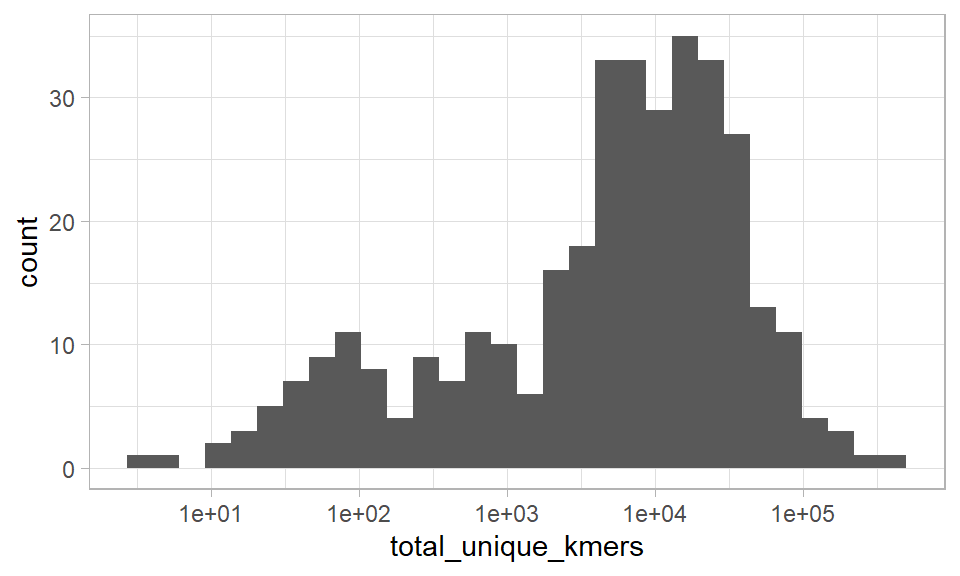

```r
se_mg |>
  as_tibble() |>
  mutate(unique_kmers = as.numeric(unique_kmers)) |>
  group_by(.sample) |>
  summarize(total_unique_kmers = sum(unique_kmers)) |>
  ggplot(aes(x = total_unique_kmers)) +
  geom_histogram() +
  scale_x_log10()
```

**Data overview**

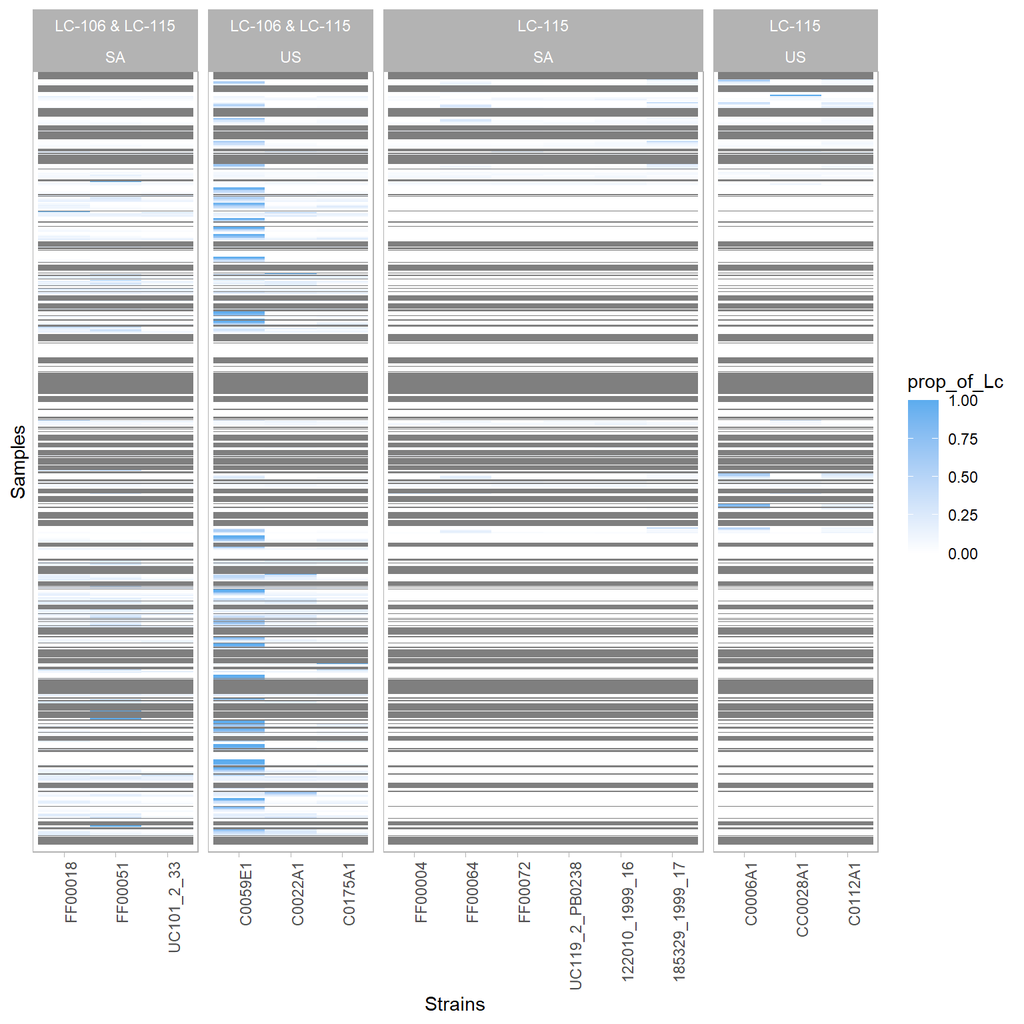

```r
se_mg |>
  as_tibble() |>
  mutate(.feature = .feature |> fct_inorder(),
         prop_of_Lc = as.numeric(prop_of_Lc)) |>
  ggplot(aes(x = .feature, y = .sample, fill = prop_of_Lc)) +
  geom_tile() +
  scale_fill_continuous(low = "white", high = "steelblue2") +
  scale_x_discrete("Strains") +
  scale_y_discrete("Samples",breaks = NULL) +
  facet_grid(. ~ LBP + strain_origin, scales = "free_x", space = "free") +
  theme(axis.text.x = element_text(angle = 90, hjust = 1))
```

### Weekly metagenomics - VIRGO2

```r
mgVirgo_to_SE <- function(mg_combined, mg_manifest, LBP_strain_info, clin){
  mg_manifest <-
    mg_manifest |>
    mutate(sample_id = str_c(pid, "_", visit_code))

  if (any(duplicated(mg_manifest$sample_id))) stop("Duplicated `uid` in `mg_manifest`")

  mg_combined <- mg_combined |> left_join(mg_manifest, by = join_by(barcode))

  tmp <- mg_combined |> dplyr::select(barcode, sample_id) |> distinct()
  if (any(duplicated(tmp$sample_id))) stop("Duplicated `uid` in `mg_combined`")

  # Add NA lines for missing samples
  all_sample_ids <-
    clin |>
    filter(!str_detect(visit_name, "Daily"), visit_abbr != "ST", day >= 0) |>
    select(sample_id) |>
    distinct() |>
    pull()

  mg_combined <-
    mg_combined |>
    complete(sample_id = all_sample_ids)

  # create assays
  assay <-
    mg_combined |>
    dplyr::select(sample_id, !all_of(LBP_strain_info$strain_id), -c(barcode, visit_code, pid, total_reads)) |>
    as.data.frame() |>
    column_to_rownames("sample_id") |>
    t()

  # Relative abundance
  rel <- t(t(assay) / colSums(assay, na.rm = TRUE)) %>% as.data.frame()

  se_coldata <-
    mg_combined |>
    dplyr::select(sample_id, barcode, total_reads) |>
    distinct() |>
    as.data.frame()

  se_rowdata <-
    mg_combined |>
    dplyr::select(-c(
      barcode,
      pid,
      visit_code,
      sample_id,
      total_reads,
      all_of(LBP_strain_info$strain_id)
    )) |>
    colnames() |>
    as.data.frame() |>
    setNames("strain") |>
    distinct() |>
    left_join(LBP_strain_info, by = join_by(strain == strain_id))

  # Harmonization of the order of samples and feature

  sorted_sample_ids <- sort(as.character(se_coldata$sample_id))
  assay <- assay[, sorted_sample_ids]
  rel <- rel[, sorted_sample_ids]
  se_coldata <- se_coldata[match(sorted_sample_ids, se_coldata$sample_id), ]

  sorted_strains <- assay |> rownames()
  assay <- assay[sorted_strains, ]
  rel <- rel[sorted_strains, ]
  se_rowdata <- se_rowdata[match(sorted_strains, se_rowdata$strain), ]

  SummarizedExperiment::SummarizedExperiment(
    assays = list(virgo2_reads = assay, virgo2_prop = rel),
    rowData = se_rowdata,
    colData = se_coldata
  )
}
```

```r
se_mg_Virgo2 <- mgVirgo_to_SE(mg_combined, mg_manifest, LBP_strain_info, clin)
```

#### Checks & Quality Controls

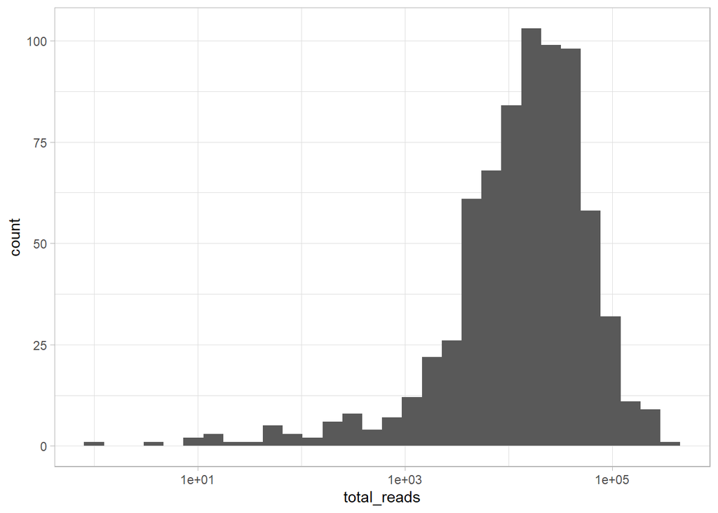

```r
se_mg_Virgo2 |>
  as_tibble() |>
  mutate(virgo2 = as.numeric(virgo2_reads)) |>
  group_by(.sample) |>
  summarize(total_reads = sum(virgo2_reads)) |>
  ggplot(aes(x = total_reads)) +
  geom_histogram() +
  scale_x_log10()
```

### Weekly 16S rRNA data

> TODO: add a summary of the protocols and methods used to generate the 16S data

We load the 16S rRNA data, which is stored as a `phyloseq` object.

```r
(w16S <- readRDS(str_c(data_dir(), "03 weekly 16S/w16S.RDS")))
```

```
phyloseq-class experiment-level object
otu_table()   OTU Table:         [ 16 taxa and 738 samples ]
sample_data() Sample Data:       [ 738 samples by 2 sample variables ]
tax_table()   Taxonomy Table:    [ 16 taxa by 9 taxonomic ranks ]
```

We transform the `phyloseq` object into a `SummarizedExperiment` object.

```r
phyloseq_to_SE <- function(physeq){

  sample_info <-
    physeq@sam_data |>
    as.data.frame() |>
    set_class("data.frame") |>
    rownames_to_column("barcode") |>
    as_tibble() |>
    mutate(sample_id = str_c(pid, "_", visit_code))

  counts <- physeq@otu_table |> as.data.frame() |> set_class("data.frame")
  if (!phyloseq::taxa_are_rows(physeq)) counts <- counts |> t()
  counts <- counts |> set_colnames(sample_info$sample_id)
  rel <- t(t(counts)/colSums(counts)) |> as.data.frame()

  SummarizedExperiment::SummarizedExperiment(
    assays = list(ASV_counts = counts, ASV_prop = rel),
    rowData = physeq@tax_table |> as.data.frame() |> set_class("data.frame"),
    colData = sample_info |> as.data.frame() |> column_to_rownames("sample_id")
  )
}
```

```r
(se_16S <- phyloseq_to_SE(w16S))
```

```
# A SummarizedExperiment-tibble abstraction: 11,808 × 16
# Features=16 | Samples=738 | Assays=ASV_counts, ASV_prop
   .feature   .sample ASV_counts ASV_prop barcode pid   visit_code asvLab asvNum
   <chr>      <chr>        <dbl>    <dbl> <chr>   <fct>      <dbl> <chr>  <chr>
 1 asv1 Lact… p1_1000         42  0.0328  16S_p1… p1          1000 "asv1… asv1
 2 asv10 Fin… p1_1000        163  0.127   16S_p1… p1          1000 "asv1… asv10
 3 asv11 Ure… p1_1000         76  0.0594  16S_p1… p1          1000 "asv1… asv11
 4 asv12 Ca.… p1_1000        316  0.247   16S_p1… p1          1000 "asv1… asv12
 5 asv13 Ato… p1_1000        147  0.115   16S_p1… p1          1000 "asv1… asv13
 6 asv14 Pre… p1_1000         15  0.0117  16S_p1… p1          1000 "asv1… asv14
 7 asv15 Str… p1_1000         16  0.0125  16S_p1… p1          1000 "asv1… asv15
 8 asv17 Pre… p1_1000         53  0.0414  16S_p1… p1          1000 "asv1… asv17
 9 asv2 Lact… p1_1000          3  0.00234 16S_p1… p1          1000 "asv2… asv2
10 asv3 Lact… p1_1000          0  0       16S_p1… p1          1000 "asv3… asv3
# ℹ 310 more rows
# ℹ 7 more variables: asvRank <chr>, Phylum <chr>, Class <chr>, Order <chr>,
#   Family <chr>, Genus <chr>, Species <chr>
```

#### Checks & Quality Controls

**16S Total reads per sample**

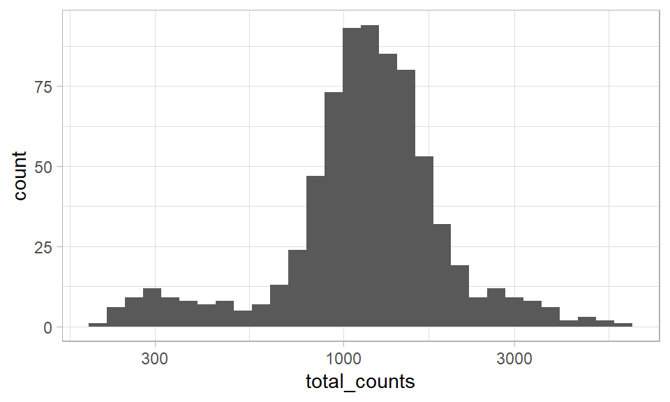

```r
se_16S |>
  as_tibble() |>
  group_by(.sample) |> summarize(total_counts = sum(ASV_counts)) |>
  ggplot(aes(x = total_counts)) +
  geom_histogram() +
  scale_x_log10()
```

**Data overview**

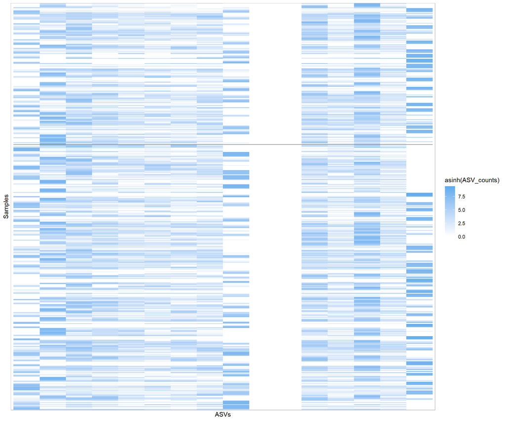

```r
se_16S |>
  as_tibble() |>
  group_by(.feature) |> mutate(total_prop = sum(ASV_prop)) |> ungroup() |>
  arrange(-total_prop) |> mutate(.feature = .feature |> fct_inorder()) |>
  ggplot(aes(x = .feature, y = .sample, fill = asinh(ASV_counts))) +
  geom_tile() +
  scale_fill_continuous(low = "white", high = "steelblue2") +
  scale_x_discrete("ASVs", breaks = NULL) +
  scale_y_discrete("Samples",breaks = NULL)
```

## Integrating all assays into a `MultiAssayExperiment` object

In this section, we assemble all `SE` objects created in the previous section into a single `MultiAssayExperiment` object.

### `colData`

```r
mae_coldata |> as_tibble()
```

```
# A tibble: 4,646 × 20
   sample_id site  arm   pid     age race     food_insecurity contraception
   <chr>     <fct> <fct> <fct> <int> <chr>    <chr>           <chr>
 1 p1_0      CAP   Pl    p1       23 Multiple No              Copper IUD
 2 p1_1000   CAP   Pl    p1       23 Multiple No              Copper IUD
 3 p1_1001   CAP   Pl    p1       23 Multiple No              Copper IUD
 4 p1_1002   CAP   Pl    p1       23 Multiple No              Copper IUD
 5 p1_1003   CAP   Pl    p1       23 Multiple No              Copper IUD
 6 p1_1004   CAP   Pl    p1       23 Multiple No              Copper IUD
 7 p1_1005   CAP   Pl    p1       23 Multiple No              Copper IUD
 8 p1_1006   CAP   Pl    p1       23 Multiple No              Copper IUD
 9 p1_1007   CAP   Pl    p1       23 Multiple No              Copper IUD
10 p1_1100   CAP   Pl    p1       23 Multiple No              Copper IUD
# ℹ 4,636 more rows
# ℹ 12 more variables: gender_sexual_partners <chr>,
#   nb_partner_pastmonth <dbl>, nb_partner_life <dbl>, dropout <lgl>,
#   dropout_time <int>, visit_code <dbl>, visit_abbr <fct>, visit_name <fct>,
#   visit_number <dbl>, day <dbl>, attended <lgl>, planned <lgl>
```

### Assays

#### Visit attendance

```r
se_va
```

```
# A SummarizedExperiment-tibble abstraction: 9,292 × 3
# Features=2 | Samples=4646 | Assays=visit_attendance
   .feature .sample visit_attendance
   <chr>    <chr>   <lgl>
 1 planned  p1_0    TRUE
 2 attended p1_0    TRUE
 3 planned  p1_1000 TRUE
 4 attended p1_1000 TRUE
 5 planned  p1_1001 TRUE
 6 attended p1_1001 TRUE
 7 planned  p1_1002 TRUE
 8 attended p1_1002 TRUE
 9 planned  p1_1003 TRUE
10 attended p1_1003 TRUE
# ℹ 30 more rows
```

#### Weekly metagenomics data with LBP strains relative abundances

```r
se_mg
```

```
# A SummarizedExperiment-tibble abstraction: 13,635 × 11
# Features=15 | Samples=909 | Assays=prop_of_Lc, unique_kmers
   .feature       .sample prop_of_Lc unique_kmers sample_id barcode strain LBP
   <chr>          <chr>        <dbl>        <dbl> <chr>     <chr>   <chr>  <fct>
 1 FF00018        p1_1000          0            0 p1_1000   mg_p1_… FF000… LC-1…
 2 FF00051        p1_1000          0            0 p1_1000   mg_p1_… FF000… LC-1…
 3 UC101_2_33     p1_1000          0            0 p1_1000   mg_p1_… UC101… LC-1…
 4 C0059E1        p1_1000          0            0 p1_1000   mg_p1_… C0059… LC-1…
 5 C0022A1        p1_1000          0            0 p1_1000   mg_p1_… C0022… LC-1…
 6 C0175A1        p1_1000          0            0 p1_1000   mg_p1_… C0175… LC-1…
 7 FF00004        p1_1000          0            0 p1_1000   mg_p1_… FF000… LC-1…
 8 FF00064        p1_1000          0            0 p1_1000   mg_p1_… FF000… LC-1…
 9 FF00072        p1_1000          0            0 p1_1000   mg_p1_… FF000… LC-1…
10 UC119_2_PB0238 p1_1000          0            0 p1_1000   mg_p1_… UC119… LC-1…
# ℹ 290 more rows
# ℹ 3 more variables: strain_origin <fct>, Biose_ID <chr>, VMRC_ID <chr>
```

#### Weekly metagenomics VIRGO2 data

```r
se_mg_Virgo2
```

```
# A SummarizedExperiment-tibble abstraction: 18,180 × 12
# Features=20 | Samples=909 | Assays=virgo2_reads, virgo2_prop
   .feature       .sample virgo2_reads virgo2_prop sample_id barcode total_reads
   <chr>          <chr>          <dbl>       <dbl> <chr>     <chr>         <dbl>
 1 "Lactobacillu… p1_1000           89     0.0106  p1_1000   mg_p1_…        8402
 2 "Bifidobacter… p1_1000            0     0       p1_1000   mg_p1_…        8402
 3 "Bifidobacter… p1_1000          818     0.0974  p1_1000   mg_p1_…        8402
 4 "Ca. Lachnocu… p1_1000          484     0.0576  p1_1000   mg_p1_…        8402
 5 "Atopobium va… p1_1000          239     0.0284  p1_1000   mg_p1_…        8402
 6 "Finegoldia m… p1_1000           19     0.00226 p1_1000   mg_p1_…        8402
 7 "Gardnerella … p1_1000          176     0.0209  p1_1000   mg_p1_…        8402
 8 "Gardnerella … p1_1000            0     0       p1_1000   mg_p1_…        8402
 9 "Gardnerella … p1_1000          202     0.0240  p1_1000   mg_p1_…        8402
10 "Gardnerella … p1_1000         2368     0.282   p1_1000   mg_p1_…        8402
# ℹ 390 more rows
# ℹ 5 more variables: strain <chr>, LBP <fct>, strain_origin <fct>,
#   Biose_ID <chr>, VMRC_ID <chr>
```

#### Weekly 16S rRNA data

```r
se_16S
```

```
# A SummarizedExperiment-tibble abstraction: 11,808 × 16
# Features=16 | Samples=738 | Assays=ASV_counts, ASV_prop
   .feature   .sample ASV_counts ASV_prop barcode pid   visit_code asvLab asvNum
   <chr>      <chr>        <dbl>    <dbl> <chr>   <fct>      <dbl> <chr>  <chr>
 1 asv1 Lact… p1_1000         42  0.0328  16S_p1… p1          1000 "asv1… asv1
 2 asv10 Fin… p1_1000        163  0.127   16S_p1… p1          1000 "asv1… asv10
 3 asv11 Ure… p1_1000         76  0.0594  16S_p1… p1          1000 "asv1… asv11
 4 asv12 Ca.… p1_1000        316  0.247   16S_p1… p1          1000 "asv1… asv12
 5 asv13 Ato… p1_1000        147  0.115   16S_p1… p1          1000 "asv1… asv13
 6 asv14 Pre… p1_1000         15  0.0117  16S_p1… p1          1000 "asv1… asv14
 7 asv15 Str… p1_1000         16  0.0125  16S_p1… p1          1000 "asv1… asv15
 8 asv17 Pre… p1_1000         53  0.0414  16S_p1… p1          1000 "asv1… asv17
 9 asv2 Lact… p1_1000          3  0.00234 16S_p1… p1          1000 "asv2… asv2
10 asv3 Lact… p1_1000          0  0       16S_p1… p1          1000 "asv3… asv3
# ℹ 310 more rows
# ℹ 7 more variables: asvRank <chr>, Phylum <chr>, Class <chr>, Order <chr>,
#   Family <chr>, Genus <chr>, Species <chr>
```

### Assembling the `MultiAssayExperiment` object

```r
assay_list <-
  list(
    visit_attendance = se_va,
    mg_ksanity = se_mg,
    mg_virgo2 = se_mg_Virgo2,
    amplicon_ASV_all = se_16S
    )


mae <-
  MultiAssayExperiment::MultiAssayExperiment(
    experiments = MultiAssayExperiment::ExperimentList(assay_list),
    colData = mae_coldata |> dplyr::rename(.sample = sample_id),
    metadata = list(data_source = data_source, date_created = today())
  )
```

```r
mae
```

```
A MultiAssayExperiment object of 4 listed
 experiments with user-defined names and respective classes.
 Containing an ExperimentList class object of length 4:
 [1] visit_attendance: SummarizedExperiment with 2 rows and 4646 columns
 [2] mg_ksanity: SummarizedExperiment with 15 rows and 909 columns
 [3] mg_virgo2: SummarizedExperiment with 20 rows and 909 columns
 [4] amplicon_ASV_all: SummarizedExperiment with 16 rows and 738 columns
Functionality:
 experiments() - obtain the ExperimentList instance
 colData() - the primary/phenotype DataFrame
 sampleMap() - the sample coordination DataFrame
 `$`, `[`, `[[` - extract colData columns, subset, or experiment
 *Format() - convert into a long or wide DataFrame
 assays() - convert ExperimentList to a SimpleList of matrices
 exportClass() - save data to flat files
```

# Checks, QC, and Outcomes Definitions

## Checks and Quality Controls

### Visualization of available data for each assay and each `site x arm x participant x visit`

```r
available_data <-
  mae[["visit_attendance"]] |>
  as_tibble() |>
  filter(.feature == "attended") |>
  dplyr::rename(attended = visit_attendance) |>
  left_join(
    mae@sampleMap |>
      as_tibble() |>
      filter(assay != "visit_attendance") |>
      mutate(.sample = primary) |>
      dplyr::select(.sample, assay),
    by = join_by(.sample)
  ) |>
  left_join(
    mae@colData |> as_tibble() |> dplyr::select(.sample, pid, site, arm, starts_with("visit_"))
  ) |>
  mutate(available_data = ifelse(attended == FALSE, FALSE, TRUE))

assay_collection_schedule <-
  available_data |>
  filter(!is.na(assay)) |>
  group_by(assay, visit_code) |>
  summarize(assay_scheduled_at_visit = !all(is.na(available_data)), .groups = "drop") |>
  filter(assay_scheduled_at_visit)

available_data <-
  available_data |>
  left_join(
    assay_collection_schedule,
    by = join_by(assay, visit_code)
  )

available_data <-
  available_data |>
  filter(assay_scheduled_at_visit)

available_data
```

```
# A tibble: 2,556 × 13
   .feature .sample attended assay       pid   site  arm   visit_code visit_abbr
   <chr>    <chr>   <lgl>    <fct>       <fct> <fct> <fct>      <dbl> <fct>
 1 attended p1_1000 TRUE     mg_ksanity  p1    CAP   Pl          1000 ENR
 2 attended p1_1000 TRUE     mg_virgo2   p1    CAP   Pl          1000 ENR
 3 attended p1_1000 TRUE     amplicon_A… p1    CAP   Pl          1000 ENR
 4 attended p1_1100 TRUE     mg_ksanity  p1    CAP   Pl          1100 Post-ABX
 5 attended p1_1100 TRUE     mg_virgo2   p1    CAP   Pl          1100 Post-ABX
 6 attended p1_1100 TRUE     amplicon_A… p1    CAP   Pl          1100 Post-ABX
 7 attended p1_1200 TRUE     mg_ksanity  p1    CAP   Pl          1200 WFU
 8 attended p1_1200 TRUE     mg_virgo2   p1    CAP   Pl          1200 WFU
 9 attended p1_1200 TRUE     amplicon_A… p1    CAP   Pl          1200 WFU
10 attended p1_1300 TRUE     mg_ksanity  p1    CAP   Pl          1300 WFU
# ℹ 2,546 more rows
# ℹ 4 more variables: visit_name <fct>, visit_number <dbl>,
#   available_data <lgl>, assay_scheduled_at_visit <lgl>
```

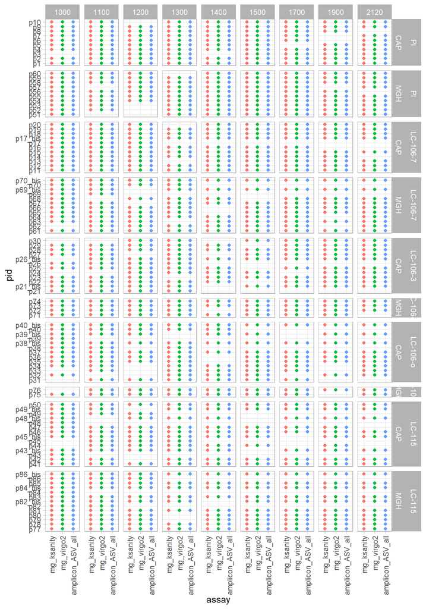

```r
available_data |>
  filter(attended == TRUE) |>  # ou available_data == TRUE
  ggplot(aes(x = assay, y = pid, col = assay)) +
  geom_point() +
  facet_grid(arm + site ~ visit_code, scales = "free", space = "free") +
  theme(axis.text.x = element_text(angle = 90, hjust = 1, vjust = 0.5), legend.position  = "none")
```

### Checking for contamination

While it is possible for a few Placebo participants to natively have strains that are extremely similar to the LBP strains, it is highly unlikely for many of the LBP strains to be present simultaneously in a single sample for a placebo participant. Such event would much more likely be the result of contamination OR a mislabeling of the sample OR a randomization issue.

We thus check how many LBP strains are simultaneously present in the Placebo participants samples

> TODO

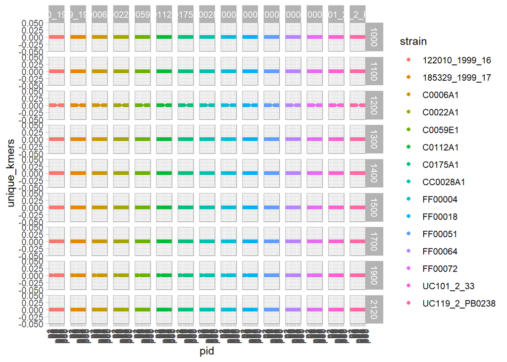

```r
mae[["mg_ksanity"]] |>
  left_join(
    colData(mae) |>
      as.tibble() |>
      dplyr::select(.sample, site, arm, visit_code, pid),
    by = ".sample"
  ) |>
  filter(arm == "Pl" & !is.na(LBP)) |>
  ggplot(aes(x = pid, y = unique_kmers, color = strain)) +
  geom_point() +
  facet_grid(visit_code ~ strain, scales = "free", space = "free") +
  theme(axis.text.x = element_text(angle = 90, hjust = 1, vjust = 0.5))
```

## Outcomes definitions

### Primary outcome definition

#### LBP strains relative abundances in each samples

This is stored in a new assay: `LBP_rel_ab`

```r
se_LBP_rel_abundances <-
  list(
    LBP_rel_ab =
      mae[["mg_ksanity"]] |>
      filter(!is.na(LBP)) |>
      left_join(
        mae[["mg_virgo2"]] |>
          filter(str_detect(.feature, "crispatus")) |>
          as_tibble() |>
          dplyr::select(.sample, virgo2_prop) |>
          group_by(.sample) |> summarize(Lc_prop = sum(virgo2_prop))
      ) |>
      mutate(
        LBP_rel_ab = prop_of_Lc * Lc_prop
      ) |>
      dplyr::select(-prop_of_Lc, -unique_kmers)
  )


mae <- c(mae, se_LBP_rel_abundances)
```

#### *At* each visit

From this, we can compute the total relative abundance of all LBP strains or the maximum relative abundance of any LBP strain in each sample.

If the total relative abundance of all LBP strains is larger than 0.1 or the maximum relative abundance of any LBP strain is larger than 0.05, we consider that the LBP achieved colonization *at* that visit.

```r
colonization <-
  mae[["LBP_rel_ab"]] |>
  as_tibble() |>
  left_join(colData(mae) |> as_tibble(),by = join_by(.sample)) |>
  group_by(.sample, pid, visit_code) |>
  summarize(
    total_prop_at = sum(LBP_rel_ab), # , na.rm = TRUE
    max_prop_at = max(LBP_rel_ab), # , na.rm = TRUE
    .groups = "drop"
  ) |>
  mutate(
    colonized_at = (total_prop_at > 0.1) | max_prop_at > 0.05
  )
```

#### *By* each visit

From the colonization status at each visit, we can compute the colonization status *by* each visit. A participant is considered to have colonized *by* a visit if they have been colonized at that visit or any previous visit.

```r
colonization <-
  colonization |>
  group_by(pid) |>
  arrange(pid, visit_code) |>
  mutate(
    colonized_by = cummax(ifelse(is.na(colonized_at), FALSE, colonized_at)) |> as.logical()
  )  |>

  # mutate(
  #   colonized_by = cumsum(colonized_at) > 0
  # ) |>

  ungroup()
```

#### Adding `primary` assay to `MAE`

```r
se_primary <-
  SummarizedExperiment(
    assays = list(
      primary =
        colonization |>
        dplyr::select(-pid, -visit_code) |>
        as.data.frame() |>
        column_to_rownames(".sample") |> t()
    )
  )

mae <- c(mae, list(LBP_colonization = se_primary))
```

### Secondary outcomes definitions

#### 16S rRNA microbiota composition, aggregated at the species level

> TODO

#### 16S rRNA microbiota composition, augmented with LBP strains relative abundances

We combine the 16S rRNA microbiota composition with the LBP strains relative abundances to create a new assay `mb_composition`.

> TODO

We now have an “augmented” `MAE` object with the following assays:

```r
mae
```

```
A MultiAssayExperiment object of 6 listed
 experiments with user-defined names and respective classes.
 Containing an ExperimentList class object of length 6:
 [1] visit_attendance: SummarizedExperiment with 2 rows and 4646 columns
 [2] mg_ksanity: SummarizedExperiment with 15 rows and 909 columns
 [3] mg_virgo2: SummarizedExperiment with 20 rows and 909 columns
 [4] amplicon_ASV_all: SummarizedExperiment with 16 rows and 738 columns
 [5] LBP_rel_ab: SummarizedExperiment with 15 rows and 909 columns
 [6] LBP_colonization: SummarizedExperiment with 4 rows and 909 columns
Functionality:
 experiments() - obtain the ExperimentList instance
 colData() - the primary/phenotype DataFrame
 sampleMap() - the sample coordination DataFrame
 `$`, `[`, `[[` - extract colData columns, subset, or experiment
 *Format() - convert into a long or wide DataFrame
 assays() - convert ExperimentList to a SimpleList of matrices
 exportClass() - save data to flat files
```

# Analyses

## Demographics (Table 1)

### Summary table

We create two summary table : one by arms and one by sites.

```r
participants_bis <-
  participants |>
  mutate(
    across(where(is.character), as.factor),
    arm = fct_recode(
      arm,
      Placebo = "Pl",
      `LC106 7 days` = "LC-106-7",
      `LC106 3 days` = "LC-106-3",
      `LC106 overlap` = "LC-106-o",
      `LC115 7 days` = "LC-115"
    ),
    site = fct_recode(
      site,
      MGH = "MGH",
      VCRS = "CAP"
    )
  ) |>
  set_variable_labels(
    food_insecurity = "Report food insecurity in past 12 months ",
    gender_sexual_partners = "Gender of sexual partners",
    nb_partner_pastmonth = "Number of partners in past month",
    nb_partner_life = "Number of partners in lifetime",
    dropout_time = "Dropout time"
  ) |>
  rename_with(~ str_to_title(.x))
```

```r
participants_bis |>
  select(-c("Pid", "Dropout_time"))  |>
  mutate(
    Arm = fct_recode(
      Arm,
      Placebo = "Placebo",
      `LC106 <br> 7 days` = "LC106 7 days",
      `LC106 <br> 3 days` = "LC106 3 days",
      `LC106 <br> overlap` = "LC106 overlap",
      `LC115 <br> 7 days` = "LC115 7 days"
    )) |>
  tbl_summary(
    by = Arm,
    type =
      list(
        Nb_partner_pastmonth ~ "continuous",
        Nb_partner_life ~ "continuous"
      ),
    statistic = list(
      all_continuous() ~ "{mean} ({sd})",
      all_categorical() ~ "{n} ({p}%)"
    )
  )  |>
  modify_spanning_header(all_stat_cols() ~ "**Treatment Received**") |>
  add_p(test = all_categorical() ~ function(data, variable, by, ...) {
    result <- fisher.test(data[[variable]], data[[by]], simulate.p.value = TRUE)
    tibble::tibble(p.value = result$p.value)},
    include = -c("Site")
    ) |>
  modify_footnote(p.value ~ "P-values from Kruskal-Wallis rank sum test and Fisher's exact test (simulated if needed).")
```

| **Characteristic** | **Treatment Received** **Placebo** N = 20<sup>1</sup> | **Treatment Received** LC106 7 days N = 23<sup>1</sup> | **Treatment Received** LC106 3 days N = 16<sup>1</sup> | **Treatment Received** LC106 overlap N = 15<sup>1</sup> | **Treatment Received** LC115 7 days N = 27<sup>1</sup> | **p-value**<sup>2</sup> |  |
| --- | --- | --- | --- | --- | --- | --- | --- |
| Site |  |  |  |  |  |  |  |
| VCRS | 10 (50%) | 11 (48%) | 12 (75%) | 13 (87%) | 14 (52%) |  |  |
| MGH | 10 (50%) | 12 (52%) | 4 (25%) | 2 (13%) | 13 (48%) |  |  |
| Age | 29 (7) | 31 (7) | 30 (7) | 28 (8) | 28 (6) | 0.5 |  |
| Race |  |  |  |  |  | 0.10 |  |
| Asian | 5 (25%) | 8 (35%) | 6 (38%) | 2 (13%) | 7 (26%) |  |  |
| Black | 4 (20%) | 10 (43%) | 2 (13%) | 2 (13%) | 9 (33%) |  |  |
| Multiple | 5 (25%) | 4 (17%) | 3 (19%) | 7 (47%) | 3 (11%) |  |  |
| White | 6 (30%) | 1 (4.3%) | 5 (31%) | 4 (27%) | 8 (30%) |  |  |
| Report food insecurity in past 12 months | 6 (30%) | 4 (17%) | 2 (13%) | 5 (33%) | 12 (44%) | 0.14 |  |
| Contraception |  |  |  |  |  | 0.14 |  |
| Combined oral contraceptive pills | 3 (15%) | 4 (17%) | 3 (19%) | 3 (20%) | 2 (7.4%) |  |  |
| Copper IUD | 2 (10%) | 2 (8.7%) | 3 (19%) | 0 (0%) | 6 (22%) |  |  |
| Depo Provera | 5 (25%) | 5 (22%) | 3 (19%) | 0 (0%) | 9 (33%) |  |  |
| Hormone containing IUD | 5 (25%) | 2 (8.7%) | 0 (0%) | 1 (6.7%) | 2 (7.4%) |  |  |
| Net EN | 3 (15%) | 8 (35%) | 3 (19%) | 6 (40%) | 5 (19%) |  |  |
| Non-hormonal method | 2 (10%) | 2 (8.7%) | 4 (25%) | 5 (33%) | 3 (11%) |  |  |
| Gender of sexual partners |  |  |  |  |  | 0.009 |  |
| Both | 3 (15%) | 6 (26%) | 4 (25%) | 1 (6.7%) | 6 (22%) |  |  |
| Female | 6 (30%) | 8 (35%) | 2 (13%) | 11 (73%) | 3 (11%) |  |  |
| Male | 11 (55%) | 9 (39%) | 10 (63%) | 3 (20%) | 18 (67%) |  |  |
| Number of partners in past month | 1.50 (2.19) | 1.22 (1.57) | 0.81 (0.66) | 1.00 (1.93) | 0.41 (0.64) | 0.15 |  |
| Number of partners in lifetime | 5.8 (3.9) | 3.7 (2.7) | 3.3 (2.3) | 4.5 (5.2) | 3.9 (3.2) | 0.3 |  |
| Dropout | 0 (0%) | 3 (13%) | 2 (13%) | 3 (20%) | 7 (26%) | 0.11 |  |

<sup>1</sup> n (%); Mean (SD)  
<sup>2</sup> P-values from Kruskal-Wallis rank sum test and Fisher’s exact test (simulated if needed).

```r
# add_p(test = all_categorical() ~ "chisq.test")
```

```r
participants_bis |>
  select(-c("Pid", "Dropout_time")) |>
  tbl_summary(
    by = Site,
    type =
      list(
        Nb_partner_pastmonth ~ "continuous",
        Nb_partner_life ~ "continuous"
      ),
    statistic = list(
      all_continuous() ~ "{mean} ({sd})",
      all_categorical() ~ "{n} ({p}%)"
    )
  )  |>
  modify_spanning_header(all_stat_cols() ~ "**Sites**") |>
  add_p(test = all_categorical() ~ function(data, variable, by, ...) {
    result <- fisher.test(data[[variable]], data[[by]], simulate.p.value = TRUE)
    tibble::tibble(p.value = result$p.value)}
    ) |>
  modify_footnote(p.value ~ "P-values from Kruskal-Wallis rank sum test and Fisher's exact test (simulated if needed).")
```

| **Characteristic** | **Sites** **VCRS** N = 60<sup>1</sup> | **Sites** **MGH** N = 41<sup>1</sup> | **p-value**<sup>2</sup> |  |
| --- | --- | --- | --- | --- |
| Arm |  |  |  | 0.063 |
| Placebo | 10 (17%) | 10 (24%) |  |  |
| LC106 7 days | 11 (18%) | 12 (29%) |  |  |
| LC106 3 days | 12 (20%) | 4 (9.8%) |  |  |
| LC106 overlap | 13 (22%) | 2 (4.9%) |  |  |
| LC115 7 days | 14 (23%) | 13 (32%) |  |  |
| Age | 30 (7) | 29 (7) | 0.6 |  |
| Race |  |  | 0.5 |  |
| Asian | 16 (27%) | 12 (29%) |  |  |
| Black | 14 (23%) | 13 (32%) |  |  |
| Multiple | 16 (27%) | 6 (15%) |  |  |
| White | 14 (23%) | 10 (24%) |  |  |
| Report food insecurity in past 12 months | 17 (28%) | 12 (29%) | >0.9 |  |
| Contraception |  |  | 0.2 |  |
| Combined oral contraceptive pills | 8 (13%) | 7 (17%) |  |  |
| Copper IUD | 11 (18%) | 2 (4.9%) |  |  |
| Depo Provera | 9 (15%) | 13 (32%) |  |  |
| Hormone containing IUD | 7 (12%) | 3 (7.3%) |  |  |
| Net EN | 15 (25%) | 10 (24%) |  |  |
| Non-hormonal method | 10 (17%) | 6 (15%) |  |  |
| Gender of sexual partners |  |  | 0.2 |  |
| Both | 9 (15%) | 11 (27%) |  |  |
| Female | 21 (35%) | 9 (22%) |  |  |
| Male | 30 (50%) | 21 (51%) |  |  |
| Number of partners in past month | 1.15 (1.74) | 0.68 (1.08) | 0.2 |  |
| Number of partners in lifetime | 4.1 (3.5) | 4.4 (3.6) | 0.6 |  |
| Dropout | 10 (17%) | 5 (12%) | 0.6 |  |

<sup>1</sup> n (%); Mean (SD)  
<sup>2</sup> P-values from Kruskal-Wallis rank sum test and Fisher’s exact test (simulated if needed).

### Graphics

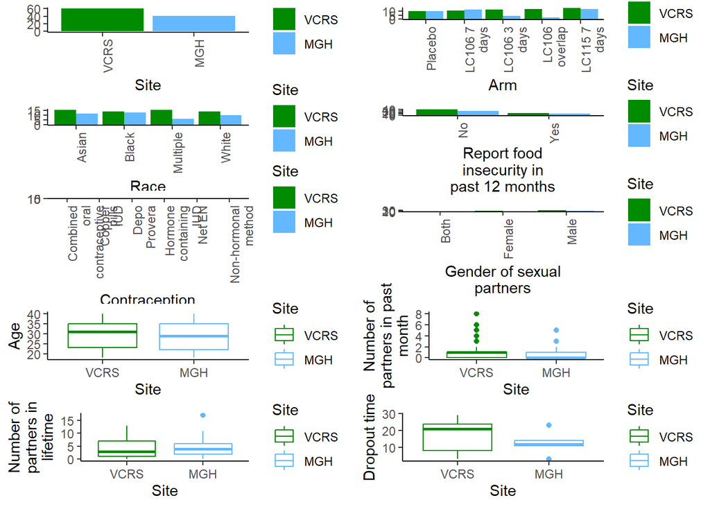

```r
cat_vars <-
  participants_bis |>
  select(where(is.factor) | where(is.character), -Pid) |>
  names()

num_vars <-
  participants_bis |>
  select(where(is.numeric) | where(is.integer)) |>
  names()

plots <- list()

custom_colors <- c("VCRS" = "green4", "MGH" = "steelblue1")

for (var in cat_vars) {
  var_label <- var_label(participants_bis[[var]])
  var_label <- ifelse(!is.null(var_label), var_label, var)

  p <-
    ggplot(participants_bis, aes_string(x = var, fill = "Site")) +
    geom_bar(position = "dodge") +
    theme_classic() +
    scale_fill_manual(values = custom_colors) +
    theme(plot.title = element_text(hjust = 0.5),
          axis.text.x = element_text(angle = 90, hjust = 1)) +
    scale_x_discrete(labels = wrap_format(10)) +
    labs(x = str_wrap(var_label, width = 17), y="")

  plots[[var]] <- p
}

for (var in num_vars) {
  var_label <- var_label(participants_bis[[var]])
  var_label <- ifelse(!is.null(var_label), var_label, var)

  p <-
    ggplot(participants_bis, aes_string(y = var, x = "Site", color = "Site")) +
    geom_boxplot() +
    theme_classic() +
    scale_color_manual(values = custom_colors) +
    theme(plot.title = element_text(hjust = 0.5)) +
    scale_x_discrete(labels = wrap_format(10)) +
    labs(y = str_wrap(var_label, width = 17))

  plots[[var]] <- p
}


ggarrange(plotlist = plots, ncol = 2, nrow = ceiling(length(plots)/2))
```

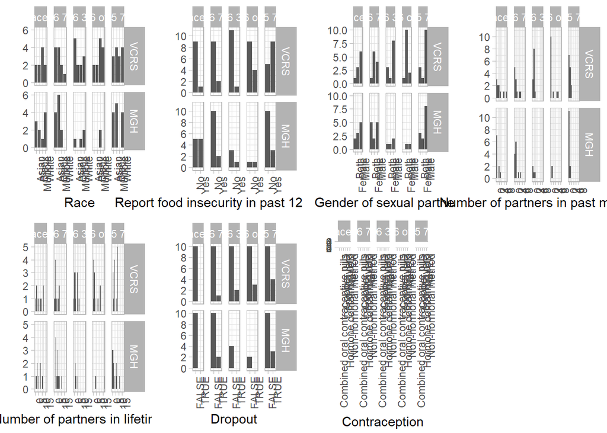

```r
p1 <- participants_bis |>
  ggplot(aes(x=Race))+
  geom_bar() +
  theme(axis.text.x = element_text(angle = 90, hjust = 1))+
  labs(y="") +
  facet_grid(Site~Arm)

p2 <- participants_bis |>
  ggplot(aes(x=Food_insecurity))+
  geom_bar() +
  theme(axis.text.x = element_text(angle = 90, hjust = 1))+
  labs(y="", x = var_label(participants_bis$Food_insecurity)) +
  scale_y_continuous(breaks = scales::pretty_breaks(n = 5))+
  facet_grid(Site~Arm)

p3 <- participants_bis |>
  ggplot(aes(x=Contraception))+
  geom_bar() +
  theme(axis.text.x = element_text(angle = 90, hjust = 1))+
  labs(y="") +
  facet_grid(Site~Arm)

p4 <- participants_bis |>
  ggplot(aes(x=Gender_sexual_partners))+
  geom_bar() +
  theme(axis.text.x = element_text(angle = 90, hjust = 1))+
  labs(y="", x = var_label(participants_bis$Gender_sexual_partners)) +
  facet_grid(Site~Arm)

p5 <- participants_bis |>
  ggplot(aes(x=Nb_partner_pastmonth))+
  geom_bar() +
  theme(axis.text.x = element_text(angle = 90, hjust = 1))+
  labs(y="", x = var_label(participants_bis$Nb_partner_pastmonth)) +
  scale_y_continuous(breaks = scales::pretty_breaks(n = 5))+
  facet_grid(Site~Arm)

p6 <- participants_bis |>
  ggplot(aes(x=Nb_partner_life))+
  geom_bar() +
  theme(axis.text.x = element_text(angle = 90, hjust = 1))+
  labs(y="", x = var_label(participants_bis$Nb_partner_life)) +
  scale_y_continuous(breaks = scales::pretty_breaks(n = 5))+
  facet_grid(Site~Arm)

p7 <- participants_bis |>
  ggplot(aes(x=Dropout))+
  geom_bar() +
  theme(axis.text.x = element_text(angle = 90, hjust = 1))+
  labs(y="") +
  scale_y_continuous(breaks = scales::pretty_breaks(n = 5))+
  facet_grid(Site~Arm)

ggarrange(p1, p2, p4, p5, p6, p7, p3, ncol=4, nrow=2)
```

## Primary outcomes (Table 2)

### Colonization by week 5

```r
#simulation
col_by_week5 <-
  expand_grid(
    site = c("MGH", "CAP") |> factor(),
    arm = c("Pl", "LC-106-7", "LC-106-3", "LC-106-o", "LC-115") |> fct_inorder(),
    pid = 1:10
  ) |>
  slice_sample(prop = 0.9) |>
  mutate(
    p = 0.0 + c(0, 0.5, 0.4, 0.7, 0.6)[arm |> as.integer()],
    colonized_by = (rbinom(n(), 1, p) == 1)
  )

col_by_week5 <-
  col_by_week5 |>
  mutate(out = (site == "MGH") & (arm %in% c("LC-106-3", "LC-106-o")) & (pid > 4)) |>
  filter(!out)
```

```r
col_by_week5 <-
  colonization |>
  left_join(colData(mae) |> as_tibble()) |>
  filter(visit_code == 1500)
```

**Visualization of the primary outcome**

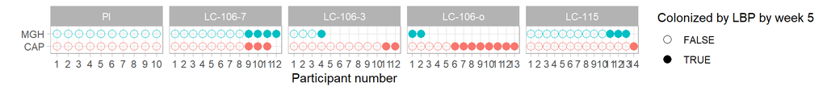

```r
col_by_week5 |>
  arrange(site, arm, colonized_by) |>
  group_by(site, arm) |>
  mutate(participant_number = row_number() |> factor()) |>
  ungroup() |>
  ggplot(aes(x = participant_number, y = site, col = site, fill = site, shape = colonized_by)) +
  geom_point(size = 3) +
  facet_grid(. ~ arm, scales = "free_x") +
  guides(color = "none", fill = "none") +
  scale_shape_manual("Colonized by LBP by week 5", values = c(1, 16)) +
  xlab("Participant number") + ylab("")
```

```r
summary_table <-
  col_by_week5 |>
  group_by(site, arm) |>
  summarize(
    n = n(),
    n_success = sum(colonized_by),
    .groups = "drop"
  ) |>
  mutate(
    p = n_success / n,
    CI = binom::binom.confint(n_success, n, method = "exact")
  )
```

```r
summary_table |>
  mutate(
    N_per_site_and_arm = str_c("N = ", n),
    LBP_strain_detected = str_c(n_success, " (", round(p * 100)," %)"),
    CI_text = str_c(round(CI$lower * 100), "% - ", round(CI$upper * 100), "%")
  ) |>
  dplyr::select(
    site, arm, N_per_site_and_arm, LBP_strain_detected, CI_text
  ) |>
  pivot_longer(-c(site, arm)) |>
  mutate(
    name =
      case_when(
        name == "N_per_site_and_arm" ~ "N participants",
        name == "LBP_strain_detected" ~ "n (%) of participants\nwith LBP strain detected",
        name == "CI_text" ~ "95% CI"
      )
  ) |>
  pivot_wider(id_cols = c(site, name), names_from = arm, values_from = value) |>
  group_by(site) |>
  gt(caption = "Table 1: Colonization by week 5 by arm and site", row_group_as_column = TRUE) |>
  cols_width(
    "name" ~ px(200),
    everything() ~ px(120)
  ) |>
  cols_label(
    name = "",
    Pl = "Placebo",
    `LC-106-7` = "LC-106<br>7 days",
    `LC-106-3` = "LC-106<br>3 days",
    `LC-106-o` = "LC-106<br>overlap",
    `LC-115` = "LC-115<br>7 days",
    .fn = md
  )
```

Table 1: Colonization by week 5 by arm and site

|  |  | Placebo | LC-106 7 days | LC-106 3 days | LC-106 overlap | LC-115 7 days |
| --- | --- | --- | --- | --- | --- | --- |
| CAP | N participants | N = 10 | N = 11 | N = 12 | N = 13 | N = 14 |
|  | n (%) of participants with LBP strain detected | 0 (0 %) | 3 (27 %) | 2 (17 %) | 8 (62 %) | 1 (7 %) |
|  | 95% CI | 0% - 31% | 6% - 61% | 2% - 48% | 32% - 86% | 0% - 34% |
| MGH | N participants | N = 10 | N = 12 | N = 4 | N = 2 | N = 13 |
|  | n (%) of participants with LBP strain detected | 0 (0 %) | 4 (33 %) | 1 (25 %) | 2 (100 %) | 3 (23 %) |
|  | 95% CI | 0% - 31% | 10% - 65% | 1% - 81% | 16% - 100% | 5% - 54% |

> TODO: include the p-values from model/test below

#### Tests / models

If we have 0 successes in none of the Placebo arm, we won’t be able to use a logistic regression model that accounts for site differences since we have a “perfect separation issue” and the odds are infinite for the Placebo arm:

```r
fit <- glm(colonized_by ~ arm + site + arm:site, data = col_by_week5, family = binomial)
fit |> summary()
```

```
Call:
glm(formula = colonized_by ~ arm + site + arm:site, family = binomial,
    data = col_by_week5)

Coefficients:
                      Estimate Std. Error z value Pr(>|z|)
(Intercept)         -1.857e+01  2.063e+03  -0.009    0.993
armLC-106-7          1.759e+01  2.063e+03   0.009    0.993
armLC-106-3          1.696e+01  2.063e+03   0.008    0.993
armLC-106-o          1.904e+01  2.063e+03   0.009    0.993
armLC-115            1.600e+01  2.063e+03   0.008    0.994
siteMGH             -9.960e-11  2.917e+03   0.000    1.000
armLC-106-7:siteMGH  2.877e-01  2.917e+03   0.000    1.000
armLC-106-3:siteMGH  5.108e-01  2.917e+03   0.000    1.000
armLC-106-o:siteMGH  1.810e+01  5.457e+03   0.003    0.997
armLC-115:siteMGH    1.361e+00  2.917e+03   0.000    1.000

(Dispersion parameter for binomial family taken to be 1)

    Null deviance: 110.762  on 100  degrees of freedom
Residual deviance:  82.053  on  91  degrees of freedom
AIC: 102.05

Number of Fisher Scoring iterations: 17
```

There are a few ways to remedy that:

```r
tmp <-
  col_by_week5 |>
  bind_rows(
    col_by_week5 |>
      dplyr::select(arm, site) |>
      distinct() |>
      mutate(colonized_by = TRUE),
    col_by_week5 |>
      dplyr::select(arm, site) |>
      distinct() |>
      mutate(colonized_by = FALSE)
  ) |>
  filter(! (arm %in% c("LC-106-3", "LC-106-o")))

fit <- glm(colonized_by ~ arm + site + arm:site, data = tmp, family = binomial)
fit |> summary()
```

```
Call:
glm(formula = colonized_by ~ arm + site + arm:site, family = binomial,
    data = tmp)

Coefficients:
                      Estimate Std. Error z value Pr(>|z|)
(Intercept)         -2.398e+00  1.044e+00  -2.296   0.0217 *
armLC-106-7          1.587e+00  1.205e+00   1.317   0.1878
armLC-115            4.520e-01  1.289e+00   0.351   0.7259
siteMGH             -5.570e-16  1.477e+00   0.000   1.0000
armLC-106-7:siteMGH  2.231e-01  1.689e+00   0.132   0.8949
armLC-115:siteMGH    9.343e-01  1.759e+00   0.531   0.5953
---
Signif. codes:  0 '***' 0.001 '**' 0.01 '*' 0.05 '.' 0.1 ' ' 1

(Dispersion parameter for binomial family taken to be 1)

    Null deviance: 83.702  on 81  degrees of freedom
Residual deviance: 77.520  on 76  degrees of freedom
AIC: 89.52

Number of Fisher Scoring iterations: 5
```

- Another way is to use an actual Bayesian model that accounts for site differences, but this does not provide p-values, only posterior distributions (and confidence intervals).

```r
col_by_week5_agg <-
  col_by_week5 |>
  group_by(site, arm) |>
  summarise(success = colonized_by |> sum(), ntrials = n())

bfit <-
  brm(
    success | trials(ntrials) ~ arm + site + arm:site,
    data = col_by_week5_agg,
    family = binomial("logit")
    )
summary(bfit)
```

```
 Family: binomial
  Links: mu = logit
Formula: success | trials(ntrials) ~ arm + site + arm:site
   Data: col_by_week5_agg (Number of observations: 10)
  Draws: 4 chains, each with iter = 2000; warmup = 1000; thin = 1;
         total post-warmup draws = 4000

Regression Coefficients:
                    Estimate Est.Error l-95% CI u-95% CI Rhat Bulk_ESS Tail_ESS
Intercept            -298.98    178.79  -631.52   -23.08 1.11       25      112
armLCM106M7           297.91    178.80    22.60   630.35 1.11       25      113
armLCM106M3           297.17    178.80    21.20   629.50 1.11       25      112
armLCM106Mo           299.50    178.81    23.77   631.87 1.11       25      112
armLCM115             295.86    178.82    20.60   627.93 1.11       25      113
siteMGH                82.76    305.48  -567.07   580.62 1.16       18       78
armLCM106M7:siteMGH   -82.45    305.49  -578.98   567.89 1.16       18       78
armLCM106M3:siteMGH   -82.46    305.51  -579.33   567.71 1.16       18       78
armLCM106Mo:siteMGH   438.44    337.41    18.21  1234.14 1.10       28       79
armLCM115:siteMGH     -80.97    305.50  -579.14   569.28 1.16       18       78

Draws were sampled using sampling(NUTS). For each parameter, Bulk_ESS
and Tail_ESS are effective sample size measures, and Rhat is the potential
scale reduction factor on split chains (at convergence, Rhat = 1).
```

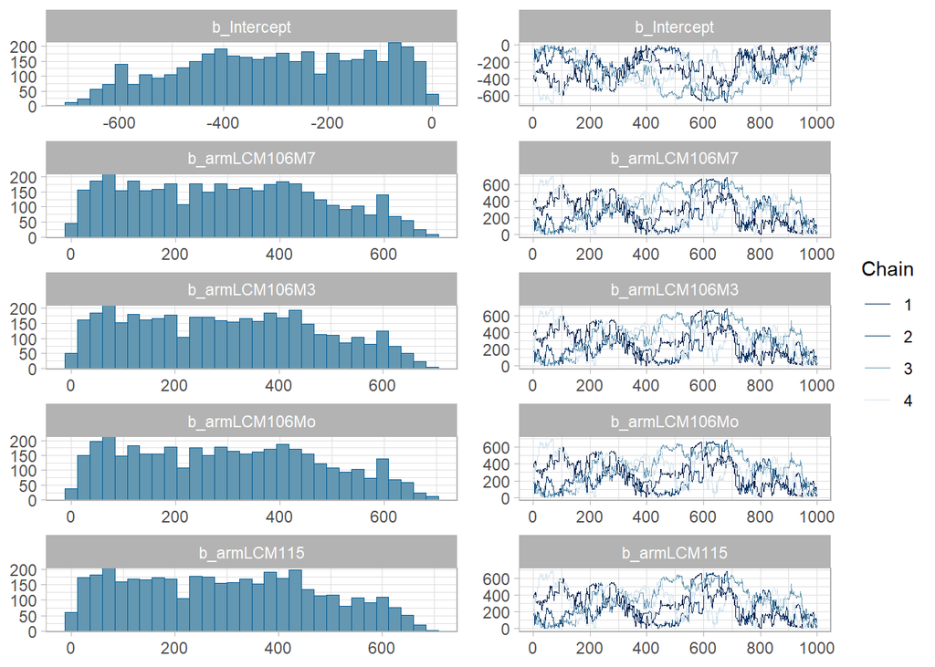

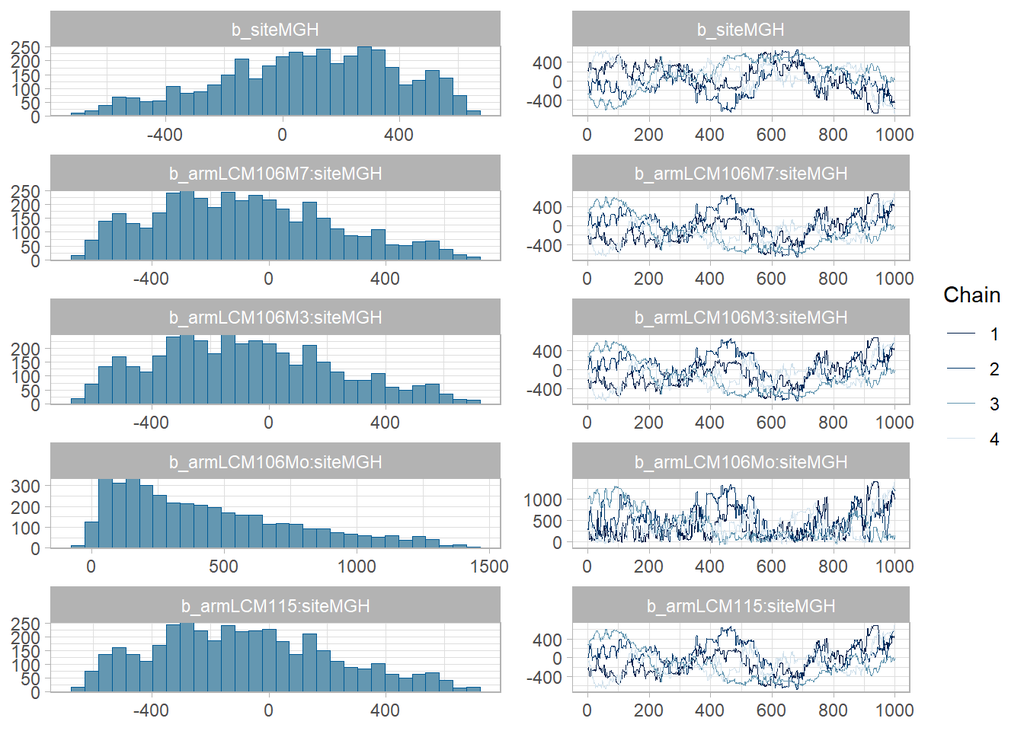

```r
plot(bfit)
```

```r
bind_cols(col_by_week5_agg, predict(bfit))
```

```
# A tibble: 10 × 8
# Groups:   site [2]
   site  arm      success ntrials Estimate Est.Error  Q2.5 Q97.5
   <fct> <fct>      <int>   <int>    <dbl>     <dbl> <dbl> <dbl>
 1 CAP   Pl             0      10  0.00125    0.0418     0     0
 2 CAP   LC-106-7       3      11  3.00       2.02       0     8
 3 CAP   LC-106-3       2      12  2.04       1.78       0     6
 4 CAP   LC-106-o       8      13  8.01       2.38       3    12
 5 CAP   LC-115         1      14  1.00       1.33       0     5
 6 MGH   Pl             0      10  0.00325    0.0651     0     0
 7 MGH   LC-106-7       4      12  4.01       2.24       0     9
 8 MGH   LC-106-3       1       4  1.01       1.11       0     4
 9 MGH   LC-106-o       2       2  2.00       0.0224     2     2
10 MGH   LC-115         3      13  3.03       2.10       0     8
```

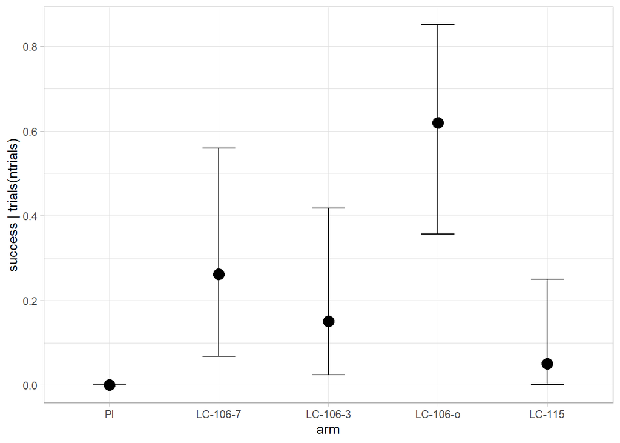

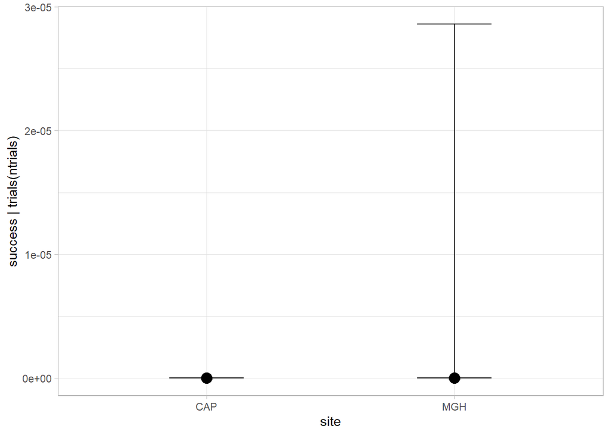

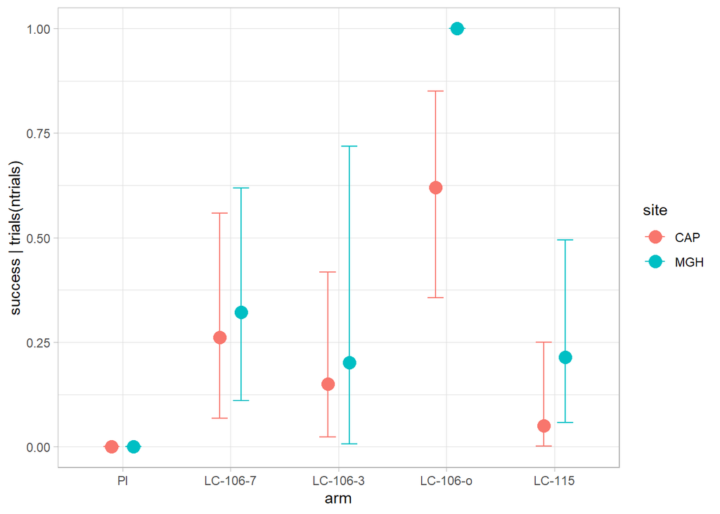

```r
plot(conditional_effects(bfit), ask = FALSE)
```

```r
# loo(bfit, moment_match = TRUE, reloo = TRUE)
# pp_check(bfit)
```

- Alternatively, we can use exact fisher tests (as initially proposed by Lara Lewis, CAPRISA) for each arm x site, correcting for multiple testing, but this does not allow us to directly test for site differences.

```r
fisher_test_res <- tibble()

for (selected_site in levels(col_by_week5$site)) {
  for (selected_arm in levels(col_by_week5$arm)[-1]) {
    ft <-
      col_by_week5 |>
      filter(site == selected_site, arm %in% c("Pl", selected_arm)) |>
      mutate(arm = arm |> fct_drop()) |>
      dplyr::select(colonized_by, arm) |>
      table() |>
      fisher.test()
    fisher_test_res <-
      fisher_test_res |>
      bind_rows(
        tibble(
          site = selected_site,
          arm = selected_arm,
          odds = ft$estimate,
          pvalue = ft$p.value
        )
      )
  }
}

fisher_test_res <-
  fisher_test_res |>
  mutate(
    qval = p.adjust(pvalue, method = "BH")
  )

fisher_test_res |>
  group_by(site) |>
  gt(caption = "Fisher exact test results")
```

[output not shown]

### Kinetics of colonization

#### Total proportions of LBP isolates

```r
g_tot_prop_LBP_strains <-
  colonization |>
  as_tibble() |>
  left_join(mae |> colData() |> as_tibble()) |>
  filter(visit_abbr != "SCR") |>
  mutate(visit_week = visit_number - 1) |>
  ggplot(aes(x = visit_week, y = total_prop_at, col = arm)) +
  geom_line(aes(group = pid), alpha = 0.5) +
  geom_point(size = 0.5, alpha = 0.5) +
  facet_grid(site ~ arm) +
  scale_x_continuous("Study weeks", breaks = c(0:5,7,9,12), minor_breaks = 0:12) +
  scale_y_continuous(
    "Total proportion of LBP strains", labels = scales::percent,
    breaks = seq(0, 1, by = 0.2)
  ) +
  expand_limits(y = 0) +
  scale_color_manual(values = get_arm_colors()) +
  guides(col = "none") +
  ggtitle(make_title(mae))
```

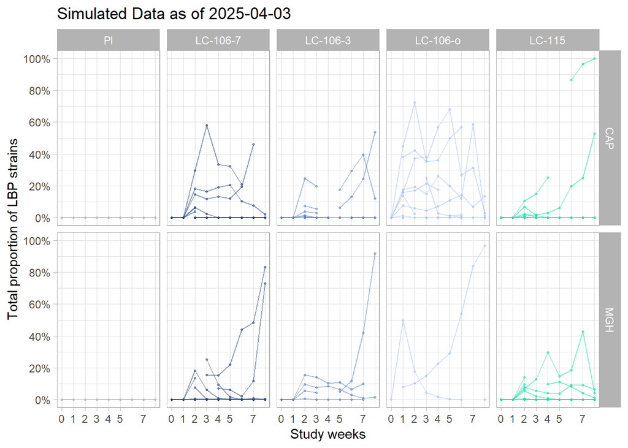

```r
g_tot_prop_LBP_strains
```

#### Proportions of participants who colonized

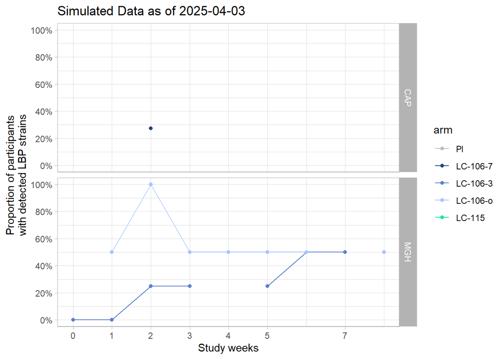

```r
g_prop_colonized_by <-
  colonization |>
  as_tibble() |>
  left_join(mae |> colData() |> as_tibble()) |>
  filter(visit_abbr != "SCR") |>
  mutate(visit_week = visit_number - 1) |>
  group_by(site, arm, visit_week) |>
  summarize(
    prop_who_colonized_at = mean(colonized_at),
    # add confidence interval
    .groups = "drop"
  ) |>
  ggplot(aes(x = visit_week, y = prop_who_colonized_at, col = arm)) +
  geom_line() +
  geom_point() +
  facet_grid(site ~ .) +
  scale_x_continuous("Study weeks", breaks = c(0:5,7,9,12), minor_breaks = 0:12) +
  scale_y_continuous(
    "Proportion of participants\nwith detected LBP strains", labels = scales::percent,
    breaks = seq(0, 1, by = 0.2)
  ) +
  expand_limits(y = 0) +
  scale_color_manual(values = get_arm_colors()) +
  ggtitle(make_title(mae))

g_prop_colonized_by
```

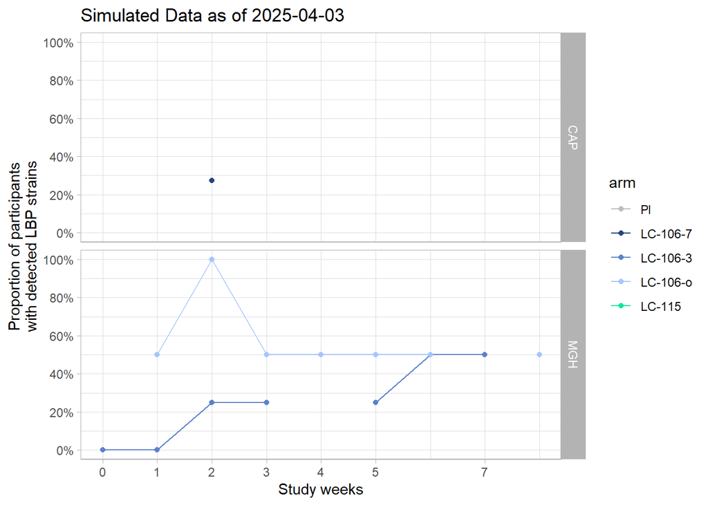

```r
g_prop_colonized_by
```

#### Figure 2

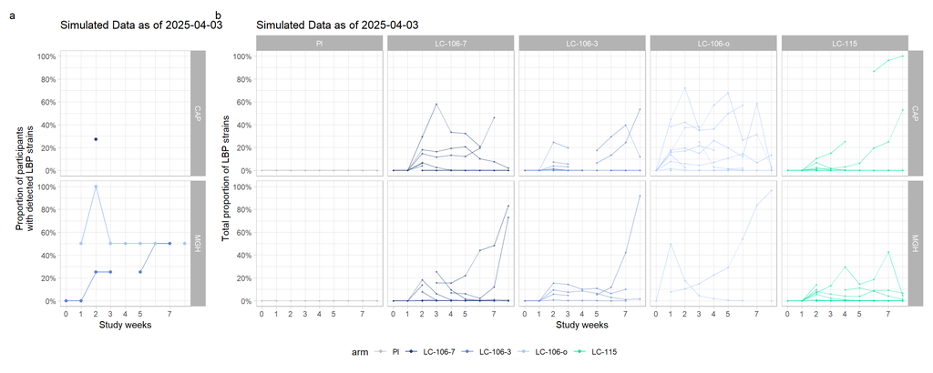

```r
 g_prop_colonized_by +
  g_tot_prop_LBP_strains +
  plot_layout(guides = "collect", widths = c(1, 5)) +
  plot_annotation(tag_level = "a") &
  theme(legend.position = "bottom")
```

### Microbiota trajectories

```r
# simplified_compositions <-
#   mae[["ASV_all"]] |>
#   as_tibble() |>
#   mutate(
#     taxa =
#       case_when(
#         str_detect(.feature, "L.crispatus[0-9]") ~ "L. crispatus (LBP strains)",
#         str_detect(.feature, "crispatus") ~ "L. crispatus (non-LBP strains)",
#         str_detect(.feature, "iners") ~ "L. iners",
#         str_detect(.feature, "Lactobacillus") ~ "other Lactobacillus spp.",
#         TRUE ~ "Non Lactobacillus spp."
#       ) |> factor()
#   ) |>
#   group_by(taxa, .sample) |>
#   summarize(prop = sum(ASV_prop), .groups = "drop") |>
#   left_join(mae |> colData() |> as_tibble(), by = join_by(.sample == sample_id))
```

```r
#
# g_trajectories <-
#   simplified_compositions |>
#   arrange_participants(by = taxa) |>
#   filter(visit_code != 0) |>
#   ggplot(aes(x = prop, y = pid, fill = taxa)) +
#   geom_col() +
#   facet_grid(site + arm ~ visit_code, scales = "free", space = "free") +
#   theme(panel.spacing.x = unit(0, "points")) +
#   scale_fill_manual(values = simplified_compositions$taxa |> levels() |> get_taxa_color()) +
#   scale_x_continuous(
#     "relative abundance", labels = scales::percent,
#     breaks = seq(0, 0.5, by = 0.5), minor_breaks = seq(0, 1, by = 0.25)
#   ) +
#   scale_y_discrete("Participants", breaks = NULL) +
#   theme(
#     strip.text.y = element_text(angle = 0, hjust = 0),
#     strip.background = element_rect(color = "white")
#   )
```

```r
# g_trajectories
```

### Individual LBP strains by sites

```r
LBP_strains <-
  mae[["LBP_rel_ab"]] |>
  as_tibble() |>
  left_join(mae |> colData() |> as_tibble())
```

```r
LBP_strains_summary <-
  LBP_strains |>
  group_by(pid, site, arm, .feature) |>
  summarize(max_prop = max(LBP_rel_ab), .groups = "drop")


LBP_strains_summary <-
  LBP_strains_summary |>
  left_join(
    mae[["mg_ksanity"]] |>
      as_tibble() |>
      dplyr::select(.feature, LBP, strain_origin) |>
      distinct(),
    by = join_by(.feature)
  )
```

```r
# LBP_strains_summary |>
#   filter(arm != "Pl") |>
#   mutate(strain_origin = str_c("orgin: ", strain_origin)) |>
#   ggplot(aes(x = site, y = max_prop, col = site, fill = site)) +
#   ggbeeswarm::geom_quasirandom(alpha = 0.7) +
#   geom_boxplot(alpha = 0.3, outlier.shape = NA) +
#   facet_grid(. ~ strain_origin + .feature) +
#   scale_color_manual(values = get_site_colors()) +
#   scale_fill_manual(values = get_site_colors()) +
#   scale_y_continuous(
#     str_c(
#       "Max. proportion of LBP strain\n",
#       "in active arms participants\n",
#       "at any weekly visit"),
#     labels = scales::percent, breaks = seq(0, 1, by = 0.05)
#     ) + expand_limits(y = 0) +
#   scale_x_discrete("", breaks = NULL) +
#   theme(
#     # strip.text.x = element_text(angle = 45),
#     legend.position = "bottom"
#   )
```

[figure not shown]

```r
LBP_strains_summary |>
  filter(arm != "Pl") |>
  group_by(site, .feature, strain_origin) |>
  summarize(prop_detected = mean(max_prop >= 0.05), .groups = "drop") |>
  mutate(origin = str_c("strain origin: ", strain_origin)) |>
  ggplot(aes(x = .feature, y = prop_detected, fill = site)) +
  geom_col(position = "dodge", width = 0.7) +
  facet_grid(. ~ origin, scale = "free", space = "free") +
  xlab("LBP strain") +
  scale_y_continuous(
    str_c(
      "Proportion of active arms participants\n",
      "with detected LBP strain\n",
      "(rel. abundance ≥ 5% at any weekly visit)"),
    labels = scales::percent, breaks = seq(0, 1, by = 0.2)
    ) +
  theme(axis.text.x = element_text(angle = 45, hjust = 1)) +
  scale_fill_manual(values = get_site_colors())
```